# Machine Learning PS I

### Programing Question

#### YU Xinghao 221022026

##### (a)

For these variables, each of them may have different impact on the home value.

*crim* Higher crime rate means more chaotic community, only few people may be interested, so it worth less. Negative effect.

*zn* Houses with larger land zone have higher home value. Positive effect.

*indus* Some industries that may cause pollution would decrease the home value, while some high-tech industries would increase the value of neighbourhoods. Unknown effect.

*chas* Houses close to the Charles river have beautiful scene, hence gain higher values. Positive effect.

*nox* Obviously, blocks with more air pollution tend to be less attractive, cheaper. Negative effect.

*rm* Obviously, houses with more bedrooms must sell for a higher price. Positive effect.

*age* Maybe some old buildings have historical meanings, some not, it’s hard to determine. Unknown effect.

*dis* If it’s far away from the employment centres, many people would dislike it due to the long on-way time. Negative effect.

*rad* If it’s more accessible to highways, it’s more convenient to parks, communities and centres around. Positive effect.

*tax* Maybe high property-tax means high housing price. Positive effect.

*ptratio* Towns with more teachers and fewer students, kids would get more educational resources. Negative effect.

*black* It’s hard to determine whether blacks would influence the home price. Unknown effect.

*lstat* Obviously, blocks with high socioeconomic people would have high house price. Negative effect.

#### (b)

```r
library(lmtest)
library(sandwich)
data("Boston", package = "MASS")
```

In general, it’s better to put all of the control variables into consideration. Plot medv against all other variables.

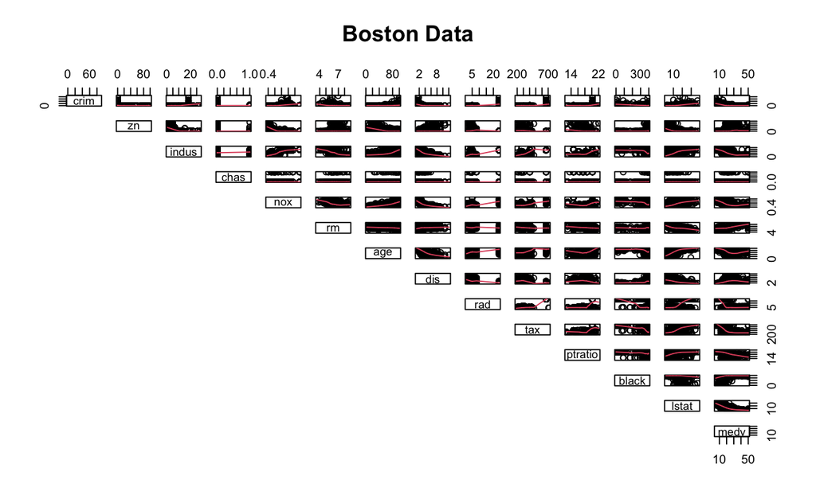

```r
pairs(Boston, panel = panel.smooth, lower.panel=NULL, main="Boston Data")
```

#### (c)

```r
fit1 <- lm(medv ~ ., Boston)
summary(fit1)
```

```
Call:
lm(formula = medv ~ ., data = Boston)

Residuals:
    Min      1Q  Median      3Q     Max
-15.595  -2.730  -0.518   1.777  26.199

Coefficients:
              Estimate Std. Error t value Pr(>|t|)
(Intercept)  3.646e+01  5.103e+00   7.144 3.28e-12 ***
crim        -1.080e-01  3.286e-02  -3.287 0.001087 **
zn           4.642e-02  1.373e-02   3.382 0.000778 ***
indus        2.056e-02  6.150e-02   0.334 0.738288
chas         2.687e+00  8.616e-01   3.118 0.001925 **
nox         -1.777e+01  3.820e+00  -4.651 4.25e-06 ***
rm           3.810e+00  4.179e-01   9.116  < 2e-16 ***
age          6.922e-04  1.321e-02   0.052 0.958229
dis         -1.476e+00  1.995e-01  -7.398 6.01e-13 ***
rad          3.060e-01  6.635e-02   4.613 5.07e-06 ***
tax         -1.233e-02  3.760e-03  -3.280 0.001112 **
ptratio     -9.527e-01  1.308e-01  -7.283 1.31e-12 ***
black        9.312e-03  2.686e-03   3.467 0.000573 ***
lstat       -5.248e-01  5.072e-02 -10.347  < 2e-16 ***
---
Signif. codes:  0 ‘***’ 0.001 ‘**’ 0.01 ‘*’ 0.05 ‘.’ 0.1 ‘ ’ 1

Residual standard error: 4.745 on 492 degrees of freedom
Multiple R-squared:  0.7406,    Adjusted R-squared:  0.7338
F-statistic: 108.1 on 13 and 492 DF,  p-value: < 2.2e-16
```

First set all the variables, and most of the estimates are statistically significant and similar to the expectation. Also it’s obviously that *indus* and *age* are not statistically insignificant, hence we could do the regression again without *indus* and *age*, then we could have the plot.

```r
Boston_Adj <- subset(Boston, select = c(-age,-indus))
#rm(Boston)
fit2 <- lm(medv ~ ., Boston_Adj)
summary(fit2)
```

```
Call:
lm(formula = medv ~ ., data = Boston_Adj)

Residuals:
     Min       1Q   Median       3Q      Max
-15.5984  -2.7386  -0.5046   1.7273  26.2373

Coefficients:
              Estimate Std. Error t value Pr(>|t|)
(Intercept)  36.341145   5.067492   7.171 2.73e-12 ***
crim         -0.108413   0.032779  -3.307 0.001010 **
zn            0.045845   0.013523   3.390 0.000754 ***
chas          2.718716   0.854240   3.183 0.001551 **
nox         -17.376023   3.535243  -4.915 1.21e-06 ***
rm            3.801579   0.406316   9.356  < 2e-16 ***
dis          -1.492711   0.185731  -8.037 6.84e-15 ***
rad           0.299608   0.063402   4.726 3.00e-06 ***
tax          -0.011778   0.003372  -3.493 0.000521 ***
ptratio      -0.946525   0.129066  -7.334 9.24e-13 ***
black         0.009291   0.002674   3.475 0.000557 ***
lstat        -0.522553   0.047424 -11.019  < 2e-16 ***
---
Signif. codes:  0 ‘***’ 0.001 ‘**’ 0.01 ‘*’ 0.05 ‘.’ 0.1 ‘ ’ 1

Residual standard error: 4.736 on 494 degrees of freedom
Multiple R-squared:  0.7406,    Adjusted R-squared:  0.7348
F-statistic: 128.2 on 11 and 494 DF,  p-value: < 2.2e-16
```

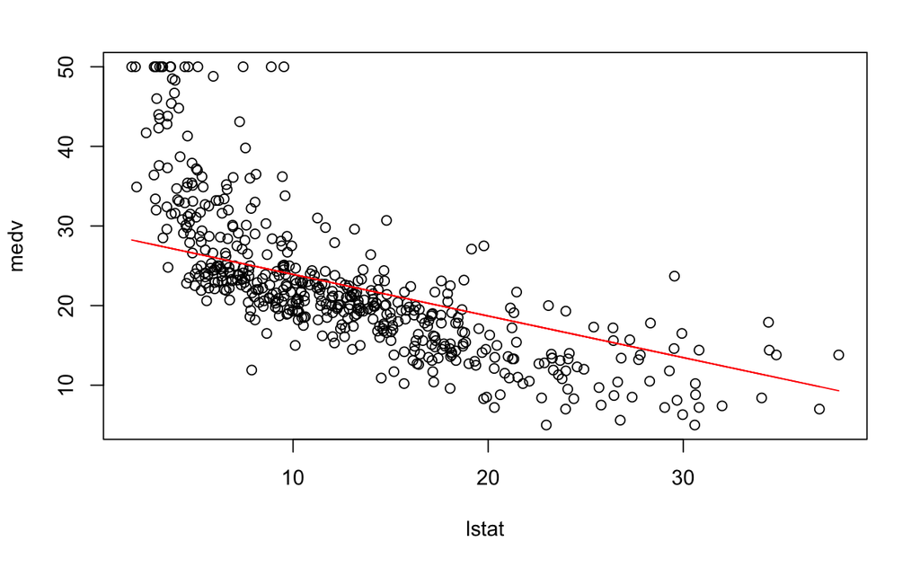

```r
mean <- c(1)
for(i in 1:10){
  mean <- c(mean, mean(Boston_Adj[,i]))
}

coff2 <- fit2$coefficients[1:11]
plot(medv ~ lstat, Boston_Adj)
lines(as.double(crossprod(coff2, mean)) + fit2$coefficients[12] * lstat ~ lstat, col = "red", Boston_Adj)
```

#### (d)

First we could using plot to discover whether there exists heteroskedasticity. And clearly, when *lstat* is pretty small or fairly large, there are several very high fitted residuals, it could be preliminary concluded that heteroskedasticity exists.

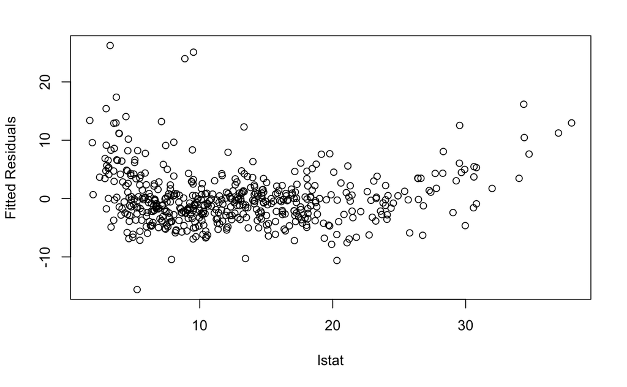

```r
fit2_res <- fit2$residuals
plot(fit2_res ~ lstat, Boston_Adj, ylab = "Fitted Residuals")
```

To judge more carefully, bptest chould be operated. And the *p-value* is less than 0.01, reject the null hypothesis, heteroskedasticity exists.

```r
bptest(fit2)
```

```
    studentized Breusch-Pagan test

data:  fit2
BP = 59.907, df = 11, p-value = 9.647e-09
```

Re-compute the standard errors and t-statistics with HC standard error.

```r
coeftest(fit2, vcov. = vcovHC(fit2, method = "white1"))
```

```
t test of coefficients:

               Estimate  Std. Error t value  Pr(>|t|)
(Intercept)  36.3411450   8.1120182  4.4799 9.287e-06 ***
crim         -0.1084133   0.0338469 -3.2030 0.0014476 **
zn            0.0458449   0.0138083  3.3201 0.0009664 ***
chas          2.7187163   1.3455538  2.0205 0.0438687 *
nox         -17.3760234   3.4185429 -5.0829 5.284e-07 ***
rm            3.8015788   0.8218324  4.6257 4.774e-06 ***
dis          -1.4927115   0.2277446 -6.5543 1.409e-10 ***
rad           0.2996085   0.0635015  4.7181 3.103e-06 ***
tax          -0.0117780   0.0029349 -4.0130 6.924e-05 ***
ptratio      -0.9465246   0.1152760 -8.2109 1.929e-15 ***
black         0.0092908   0.0027637  3.3618 0.0008344 ***
lstat        -0.5225535   0.0882650 -5.9203 6.020e-09 ***
---
Signif. codes:  0 ‘***’ 0.001 ‘**’ 0.01 ‘*’ 0.05 ‘.’ 0.1 ‘ ’ 1
```

#### (e)

Add the interaction term on basis of set of all variables (*indus* and *age* included).

```r
fit3 <- lm(medv ~ . + lstat * age, Boston)
summary(fit3)
```

```
Call:
lm(formula = medv ~ . + lstat * age, data = Boston)

Residuals:
     Min       1Q   Median       3Q      Max
-15.4559  -2.7480  -0.5557   1.8049  26.2582

Coefficients:
              Estimate Std. Error t value Pr(>|t|)
(Intercept)  38.034385   5.467840   6.956 1.12e-11 ***
crim         -0.111723   0.033199  -3.365 0.000825 ***
zn            0.043109   0.014336   3.007 0.002774 **
indus         0.018945   0.061550   0.308 0.758365
chas          2.709592   0.862357   3.142 0.001779 **
nox         -18.026578   3.834758  -4.701 3.37e-06 ***
rm            3.759388   0.422759   8.893  < 2e-16 ***
age          -0.010315   0.019023  -0.542 0.587897
dis          -1.475346   0.199527  -7.394 6.19e-13 ***
rad           0.307676   0.066401   4.634 4.61e-06 ***
tax          -0.012335   0.003762  -3.279 0.001116 **
ptratio      -0.958239   0.131052  -7.312 1.08e-12 ***
black         0.009187   0.002691   3.414 0.000694 ***
lstat        -0.635696   0.146950  -4.326 1.84e-05 ***
age:lstat     0.001257   0.001562   0.804 0.421562
---
Signif. codes:  0 ‘***’ 0.001 ‘**’ 0.01 ‘*’ 0.05 ‘.’ 0.1 ‘ ’ 1

Residual standard error: 4.747 on 491 degrees of freedom
Multiple R-squared:  0.741, Adjusted R-squared:  0.7336
F-statistic: 100.3 on 14 and 491 DF,  p-value: < 2.2e-16
```

Obviously this interaction term is not statistically significant, hence the result has not been changed so far.

#### (f)

Add the second order term of *lstat* on basis of set of adjusted variables (*indus* and *age* excluded).

```r
fit4 <- lm(medv ~ . + I(lstat^2), Boston_Adj)
summary(fit4)
```

```
Call:
lm(formula = medv ~ . + I(lstat^2), data = Boston_Adj)

Residuals:
     Min       1Q   Median       3Q      Max
-17.5603  -2.6709  -0.3071   1.9469  25.0085

Coefficients:
              Estimate Std. Error t value Pr(>|t|)
(Intercept)  42.124187   4.632559   9.093  < 2e-16 ***
crim         -0.149072   0.030006  -4.968 9.34e-07 ***
zn            0.021281   0.012500   1.703 0.089291 .
chas          2.589821   0.775307   3.340 0.000900 ***
nox         -13.534522   3.229619  -4.191 3.30e-05 ***
rm            3.233174   0.372802   8.673  < 2e-16 ***
dis          -1.357892   0.169051  -8.032 7.09e-15 ***
rad           0.271744   0.057599   4.718 3.11e-06 ***
tax          -0.009546   0.003068  -3.111 0.001970 **
ptratio      -0.790820   0.118089  -6.697 5.82e-11 ***
black         0.008174   0.002429   3.365 0.000824 ***
lstat        -1.669567   0.119012 -14.029  < 2e-16 ***
I(lstat^2)    0.033055   0.003198  10.337  < 2e-16 ***
---
Signif. codes:  0 ‘***’ 0.001 ‘**’ 0.01 ‘*’ 0.05 ‘.’ 0.1 ‘ ’ 1

Residual standard error: 4.298 on 493 degrees of freedom
Multiple R-squared:  0.7868,    Adjusted R-squared:  0.7816
F-statistic: 151.6 on 12 and 493 DF,  p-value: < 2.2e-16
```

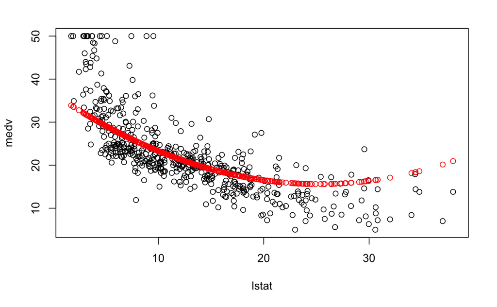

```r
coff4 <- fit4$coefficients[1:11]
plot(medv ~ lstat, Boston_Adj)
points(as.double(crossprod(coff4, mean)) + fit4$coefficients[12] * lstat + fit4$coefficients[13] * lstat^2 ~ lstat, col = "red", Boston_Adj)
```

#### (g)

Add higher order terms of *lstat* on basis of set of adjusted variables (*indus* and *age* excluded).

```r
fit5 <- lm(medv ~ . + poly(lstat, 4, raw = TRUE), Boston_Adj)
summary(fit5)
```

```
Call:
lm(formula = medv ~ . + poly(lstat, 4, raw = TRUE), data = Boston_Adj)

Residuals:
     Min       1Q   Median       3Q      Max
-15.4703  -2.4562  -0.2496   1.9028  26.5054

Coefficients: (1 not defined because of singularities)
                              Estimate Std. Error t value Pr(>|t|)
(Intercept)                  5.683e+01  5.340e+00  10.643  < 2e-16 ***
crim                        -1.491e-01  2.916e-02  -5.112 4.57e-07 ***
zn                           1.068e-02  1.235e-02   0.864 0.387742
chas                         2.136e+00  7.580e-01   2.818 0.005030 **
nox                         -1.385e+01  3.145e+00  -4.405 1.30e-05 ***
rm                           2.747e+00  3.858e-01   7.120 3.86e-12 ***
dis                         -1.260e+00  1.652e-01  -7.627 1.26e-13 ***
rad                          2.792e-01  5.600e-02   4.985 8.59e-07 ***
tax                         -1.070e-02  2.989e-03  -3.580 0.000378 ***
ptratio                     -8.504e-01  1.153e-01  -7.378 6.89e-13 ***
black                        8.680e-03  2.362e-03   3.675 0.000264 ***
lstat                       -5.136e+00  6.331e-01  -8.111 4.05e-15 ***
poly(lstat, 4, raw = TRUE)1         NA         NA      NA       NA
poly(lstat, 4, raw = TRUE)2  3.814e-01  6.320e-02   6.036 3.13e-09 ***
poly(lstat, 4, raw = TRUE)3 -1.327e-02  2.486e-03  -5.339 1.43e-07 ***
poly(lstat, 4, raw = TRUE)4  1.683e-04  3.318e-05   5.072 5.59e-07 ***
---
Signif. codes:  0 ‘***’ 0.001 ‘**’ 0.01 ‘*’ 0.05 ‘.’ 0.1 ‘ ’ 1

Residual standard error: 4.177 on 491 degrees of freedom
Multiple R-squared:  0.7995,    Adjusted R-squared:  0.7938
F-statistic: 139.8 on 14 and 491 DF,  p-value: < 2.2e-16
```

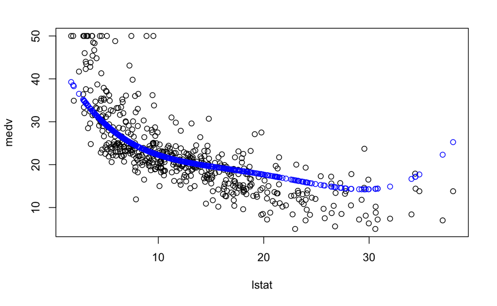

```r
coff5 <- fit5$coefficients[1:11]
plot(medv ~ lstat, Boston_Adj)
points(as.double(crossprod(coff5, mean)) + fit5$coefficients[12] * lstat + fit5$coefficients[14] * lstat^2
       + fit5$coefficients[15] * lstat^3 + fit5$coefficients[16] * lstat^4 ~ lstat, col = "blue", Boston_Adj)
```

#### (h)

To choose the best fitted model, perform BIC measurements (AIC at log(n) degree). And we know that the smaller BIC a model get, the better fitting ability a model has. Therefore the regression with higher order terms (fit 5) is the best, as it obtain the smallest BIC.

```r
medv.n <- nrow(Boston_Adj)

AIC(fit2, fit4, fit5, k = log(medv.n))
```

|  | df | AIC |
| --- | --- | --- |
| fit2 | 13 | 3078.671 |
| fit4 | 14 | 2985.626 |
| fit5 | 16 | 2967.071 |

#### (i)

For the best model (fit 5), using bootstrap method (B = 10000) to determine the regression uncertainty.

```r
B <- 10000
k <- length(coef(fit5))

BC <- matrix(nrow = B, ncol = k, dimnames = list(paste("Sample",1:B),names(coef(fit5))))

set.seed(114514)
for (i in 1:B) {
  boot.data <- Boston_Adj[sample(x = 1:medv.n, size = medv.n, replace = TRUE), ]
  bootfit <- lm(medv ~ . + poly(lstat, 4, raw = TRUE), boot.data)
  BC[i, ] <- coef(bootfit)
}
head(BC)
```

```
         (Intercept)       crim           zn     chas        nox       rm       dis       rad          tax    ptratio
Sample 1    63.82911 -0.1197276  0.025138299 3.782324 -15.077334 1.761520 -1.589883 0.2883505 -0.010861130 -0.7439481
Sample 2    51.94113 -0.1348041  0.020165797 3.924375 -13.242653 2.823931 -1.187337 0.2990158 -0.011911976 -0.8761002
Sample 3    53.15933 -0.2216876  0.027722243 2.449814  -9.360598 2.912142 -1.254620 0.3357499 -0.013578663 -0.6918903
Sample 4    42.90811 -0.1300106 -0.001358229 2.165590 -13.908866 4.432212 -1.191329 0.2457556 -0.008074610 -0.8982159
Sample 5    51.16825 -0.1308161  0.023697443 3.798634  -9.539553 2.686253 -1.052968 0.2281790 -0.009942406 -0.7893099
Sample 6    51.09232 -0.1306908  0.013885980 2.196468 -10.402242 3.103938 -1.210309 0.3044948 -0.013095703 -0.8646847
               black     lstat poly(lstat, 4, raw = TRUE)1 poly(lstat, 4, raw = TRUE)2 poly(lstat, 4, raw = TRUE)3
Sample 1 0.006049529 -4.702286                          NA                   0.3213841                -0.010958850
Sample 2 0.004758459 -3.610363                          NA                   0.2521935                -0.008948167
Sample 3 0.008800670 -6.105407                          NA                   0.5152585                -0.020180011
Sample 4 0.008532793 -4.211700                          NA                   0.3117532                -0.011168441
Sample 5 0.011204067 -5.004140                          NA                   0.3676093                -0.012581777
Sample 6 0.009259867 -4.664700                          NA                   0.3491046                -0.012474282
         poly(lstat, 4, raw = TRUE)4
Sample 1                0.0001393442
Sample 2                0.0001191474
Sample 3                0.0002827809
Sample 4                0.0001459152
Sample 5                0.0001568942
Sample 6                0.0001626799
```

Remove the repeat *lstat* column and check the mean values and variance of the coefficients.

```r
BC <- BC[ , -13]
colMeans(BC, na.rm = T)
```

```
                (Intercept)                        crim                          zn                        chas
               56.238836065                -0.152238866                 0.010855452                 2.141792843
                        nox                          rm                         dis                         rad
              -13.703255147                 2.816736949                -1.248977150                 0.280610324
                        tax                     ptratio                       black                       lstat
               -0.010827941                -0.846996628                 0.008779185                -5.208626862
poly(lstat, 4, raw = TRUE)2 poly(lstat, 4, raw = TRUE)3 poly(lstat, 4, raw = TRUE)4
                0.393602211                -0.013903688                 0.000178617
```

```r
apply(BC, 2, var)
```

```
                (Intercept)                        crim                          zn                        chas
               7.178557e+01                8.738844e-04                1.639812e-04                1.326596e+00
                        nox                          rm                         dis                         rad
               7.203935e+00                5.564597e-01                3.881698e-02                2.588416e-03
                        tax                     ptratio                       black                       lstat
               6.176497e-06                1.168914e-02                4.555809e-06                8.212024e-01
poly(lstat, 4, raw = TRUE)2 poly(lstat, 4, raw = TRUE)3 poly(lstat, 4, raw = TRUE)4
               7.629498e-03                1.157226e-05                2.093957e-09
```

For each coefficients, draw the density histgram.

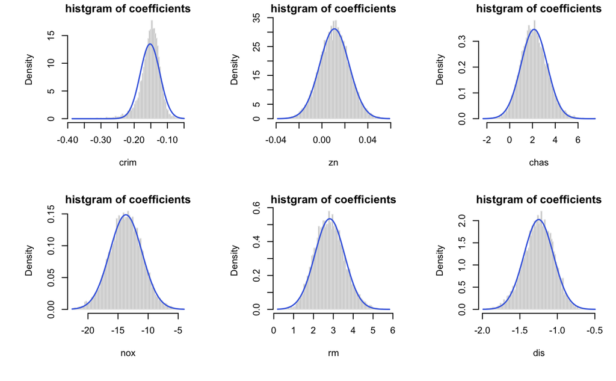

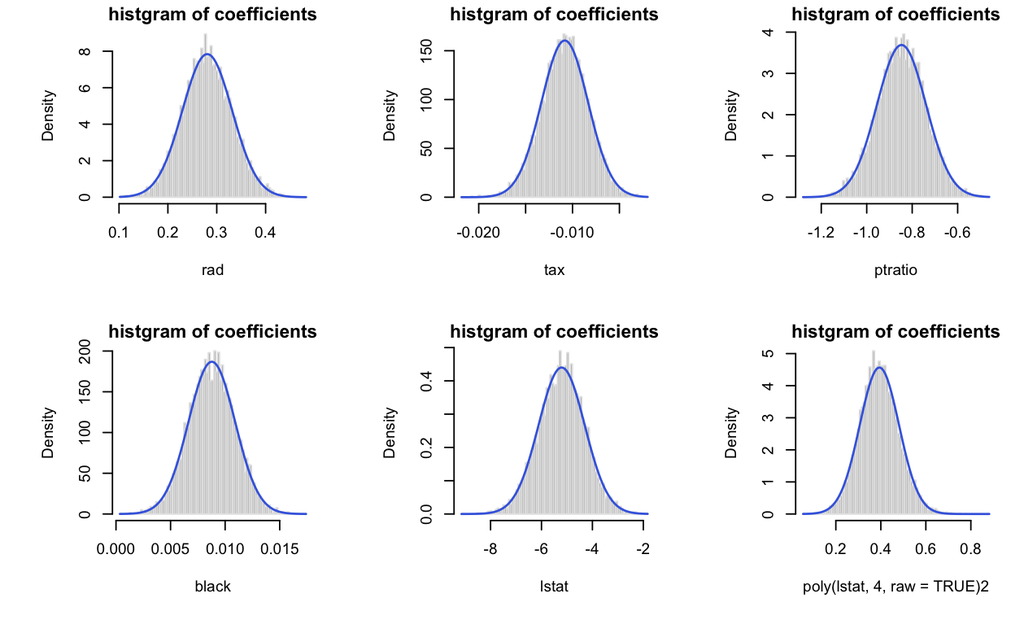

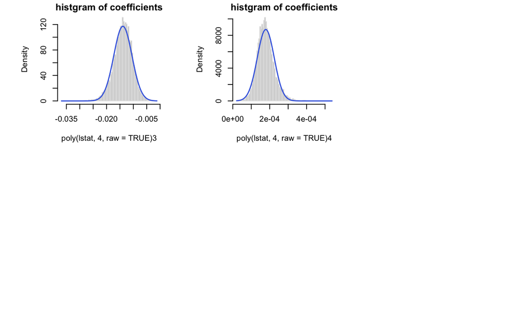

```r
par(mfrow=c(2,3))
for (c in 2:ncol(BC)) {
  xx <- seq(min(BC[ , c]), max(BC[ , c]), length=100)
  par(mai = c(.8, .8, .2, .2))
  hist(BC[ , c], breaks = xx, main = "histgram of coefficients", xlab = colnames(BC)[c],
     col = 8, border = "grey90", freq = FALSE)
  lines(xx, dnorm(xx, mean(BC[ , c]), sd(BC[ , c])), col = "royalblue", lwd = 1.5)
}
```